# Gas Cost Estimator: estimation of gas costs using the measure marginal method

In this script, there is conducted the estimation for the `measure_marginal` approach for a single given env. The programs is the set of bytecode programs with varying number of opcodes. The measurements are time measurements of program runs or benchmarks. The estimation of each opcode is calculated as the regression against the number of a given opcode in the executed programs.

Parametrization. The evm client name env=geth, the file with programs programs=pg_precompiles_full_step5.csv, the file with measurements results=results_precompiles_full_geth.csv,  
the output csv file with estimated cost output_estimated_cost=reports-08.11.2024/estimated_cost_geth_precompiles.csv, should the details be included in the report details=FALSE.

```r
if (removed_outliers) {
  measurements = remove_compare_outliers(measurements, 'measure_total_time_ns', c(env))
}
```

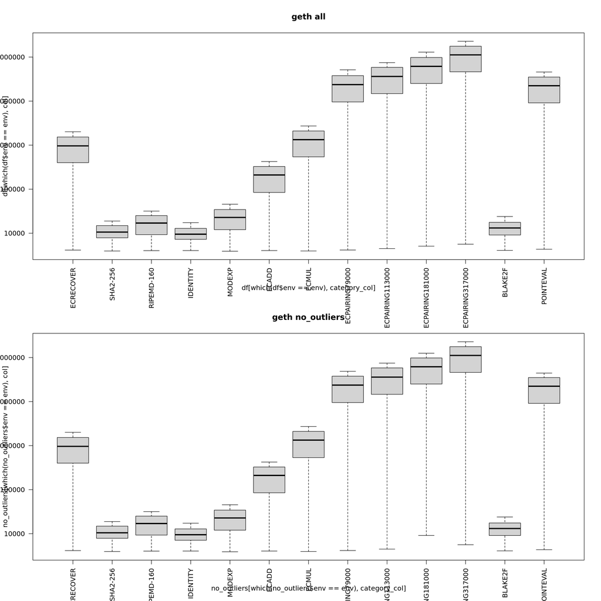

Now we can investigate the linear regressions.

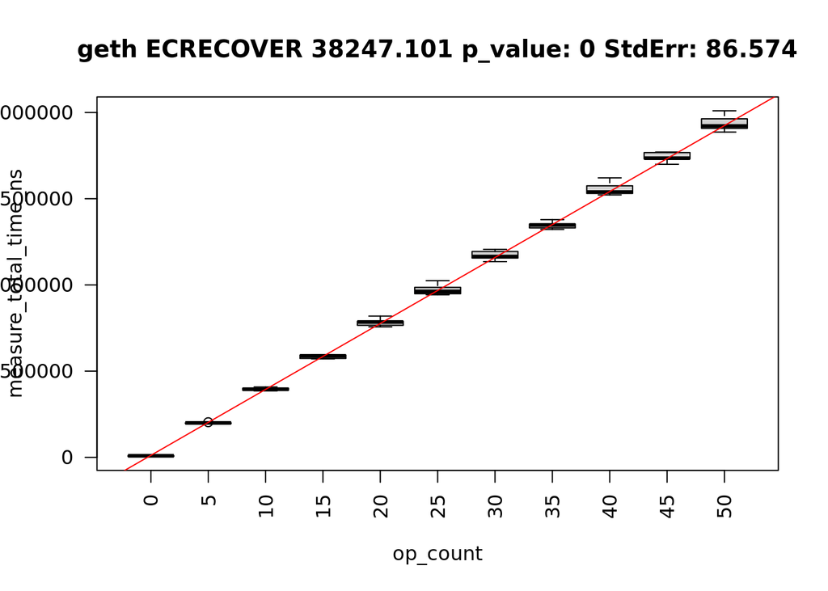

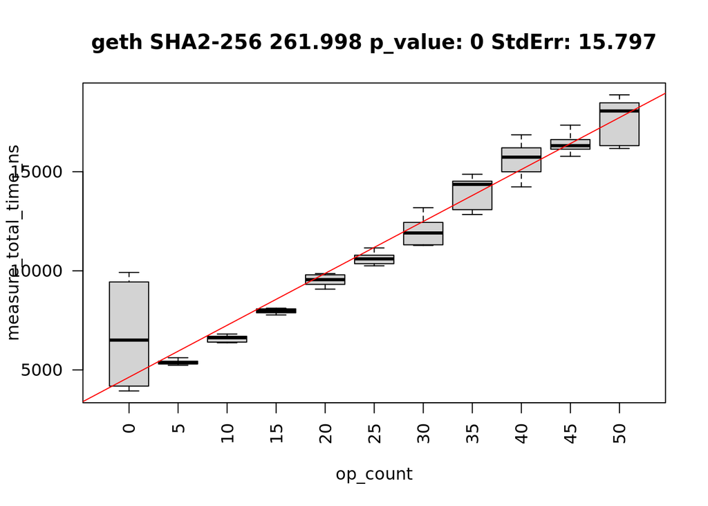

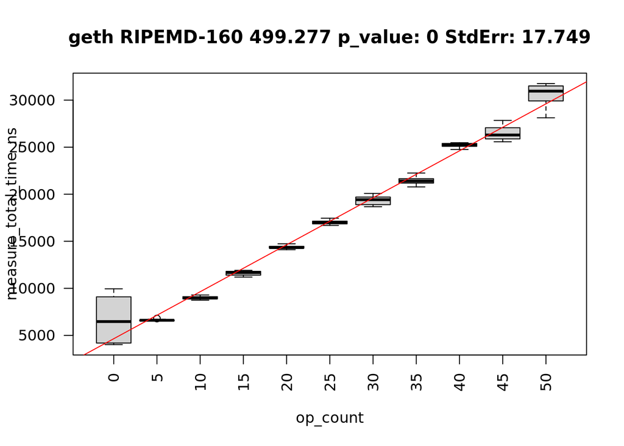

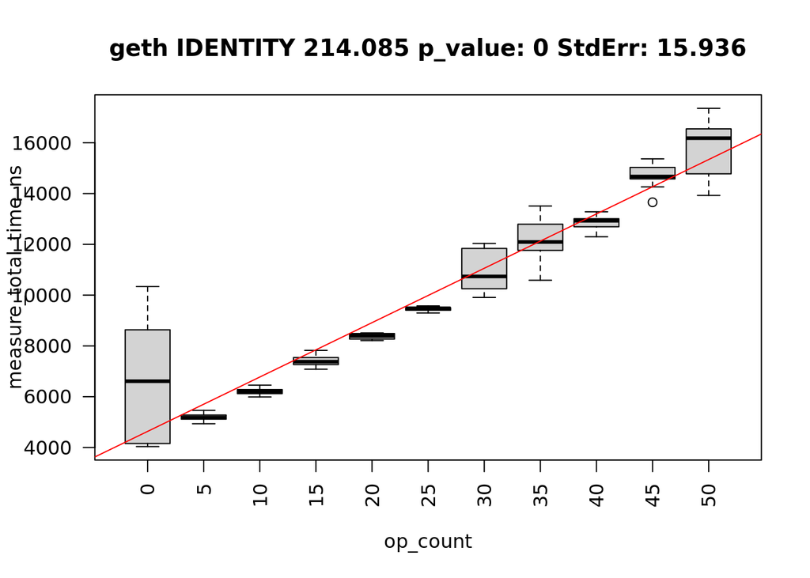

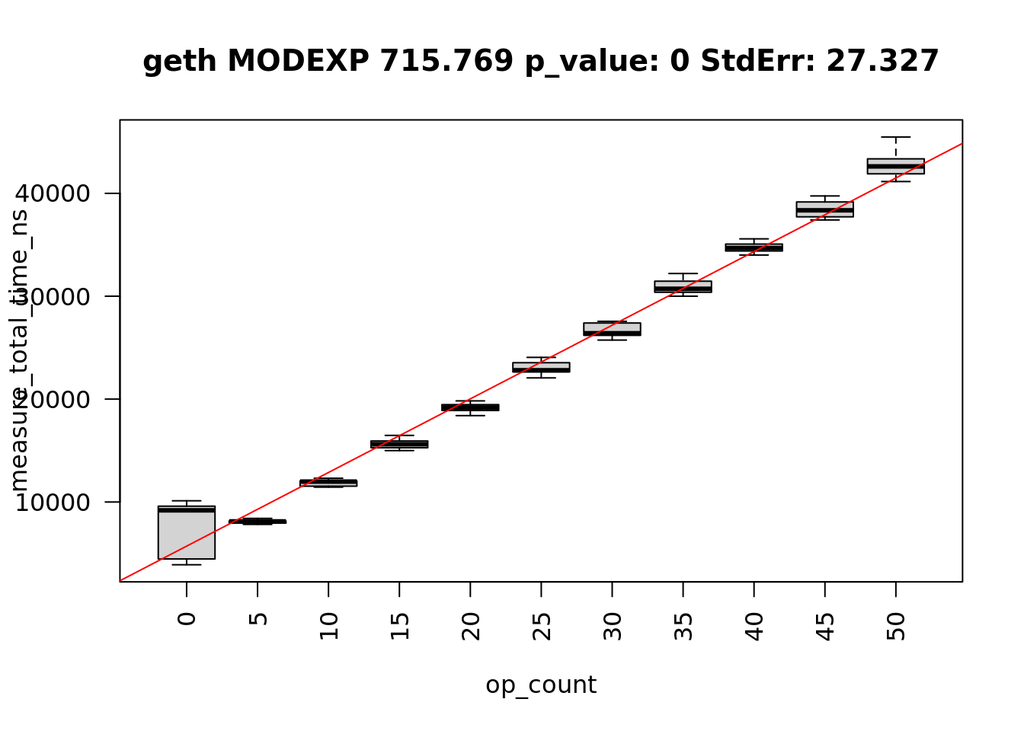

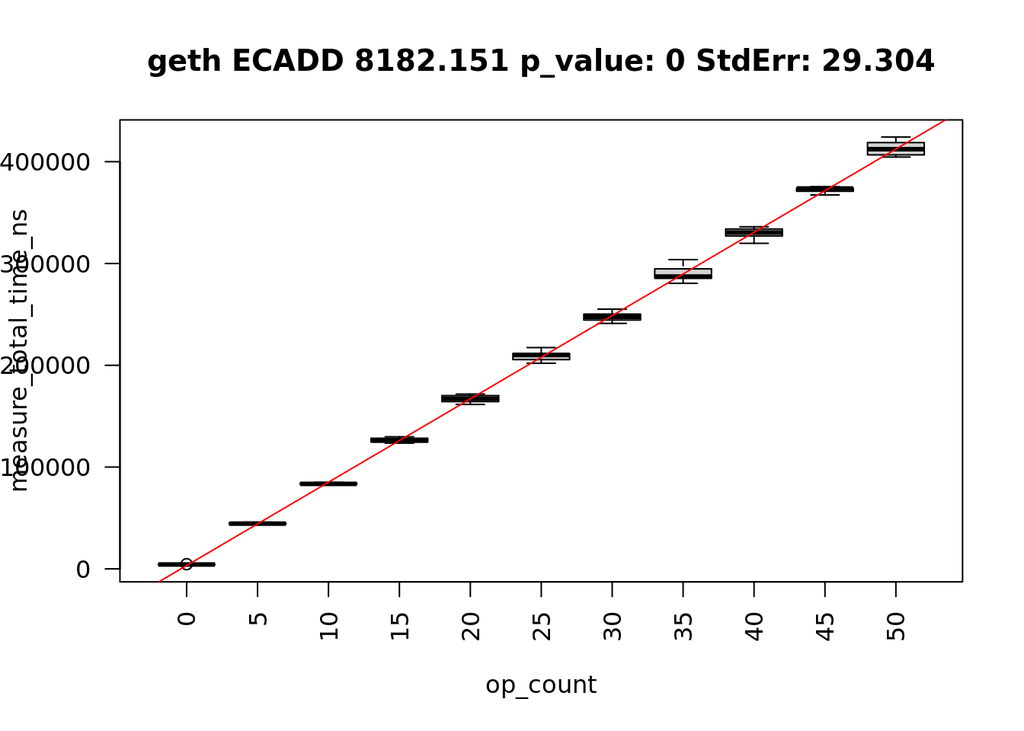

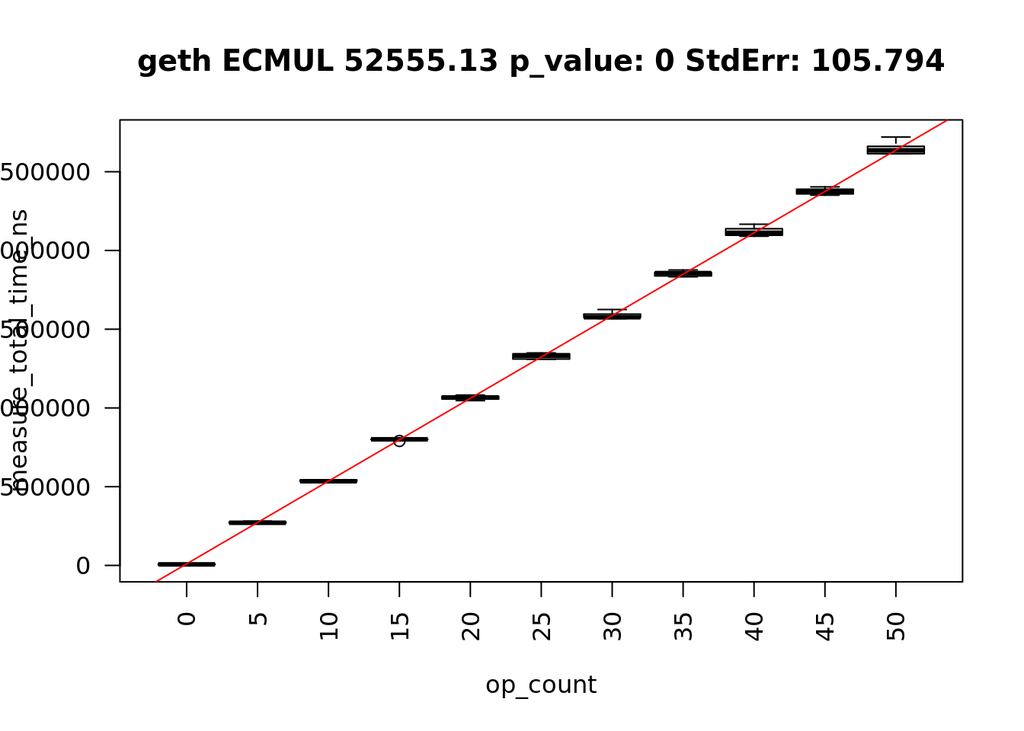

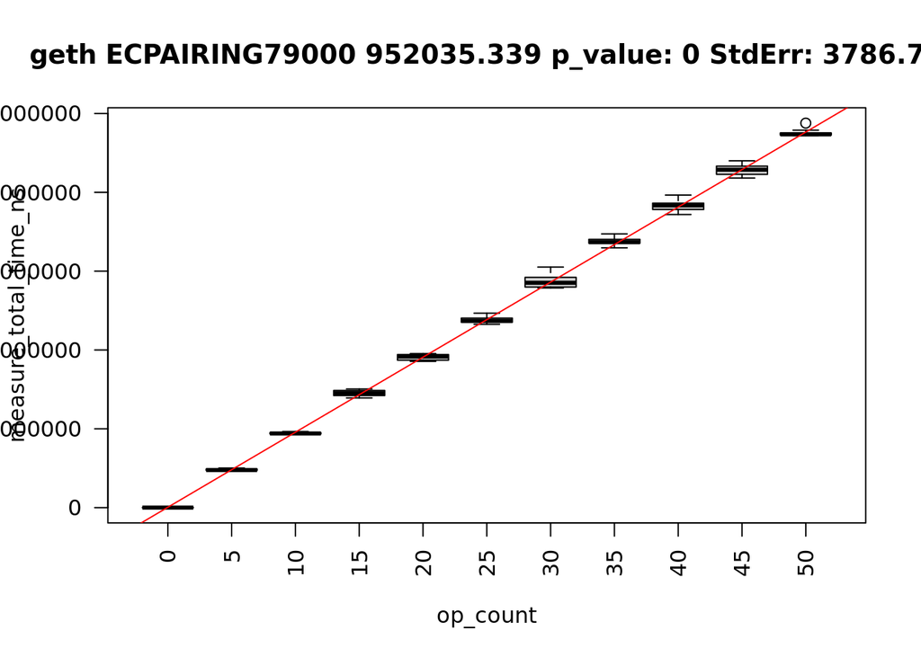

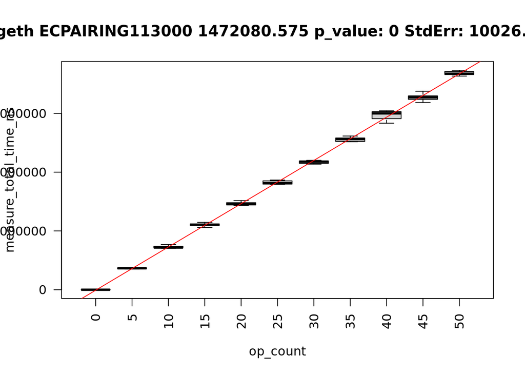

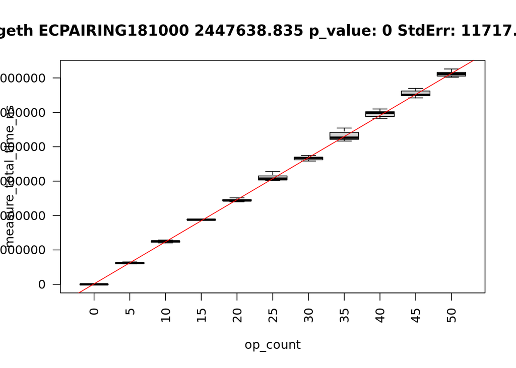

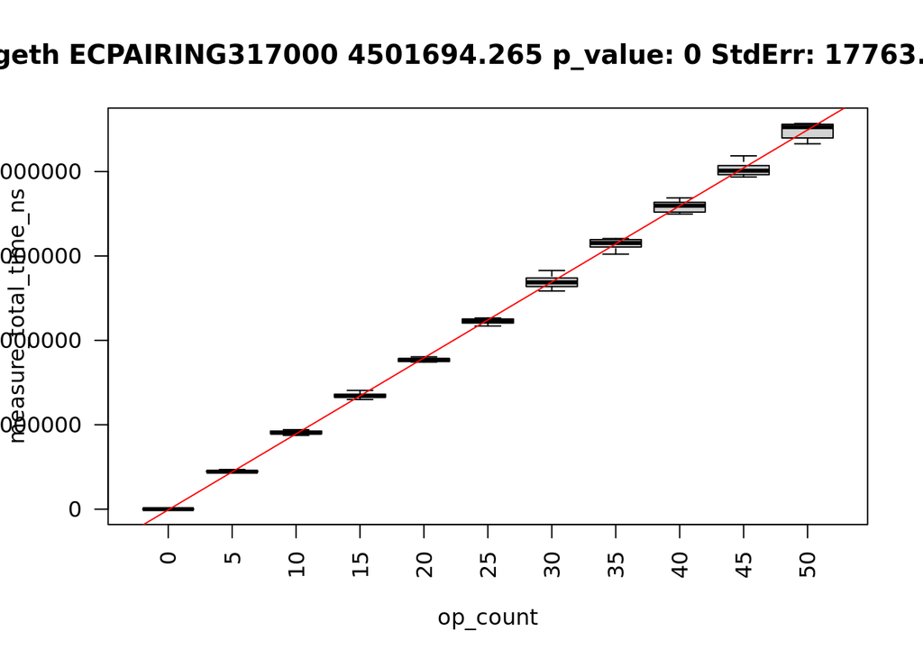

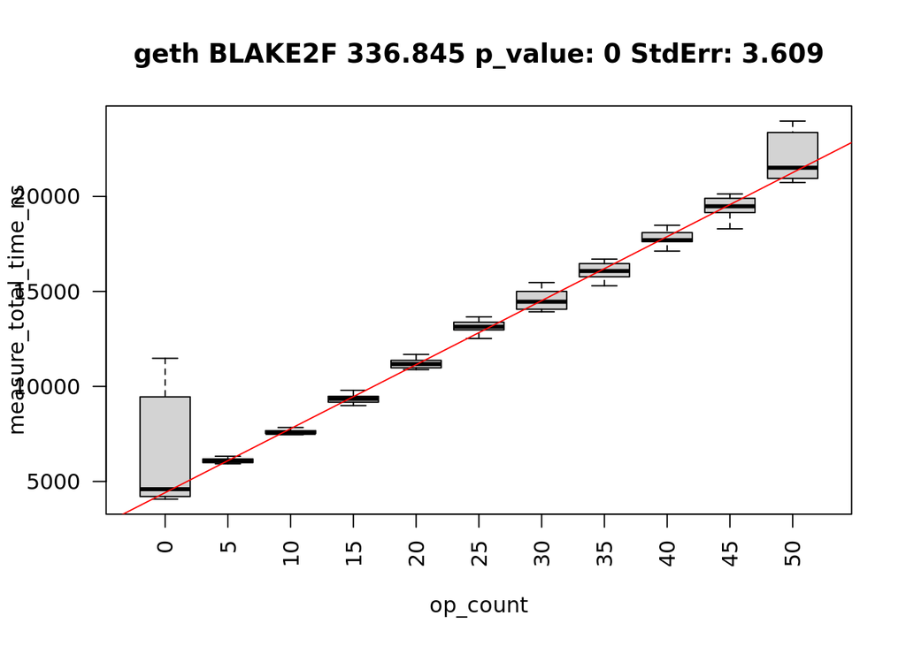

[1 more figures not shown]

```r
for (opcode in all_opcodes) {
  estimate = compute_all(opcode=opcode, env=env, use_median=TRUE, plots=ifelse(details,'all','scatter'))
  estimates[nrow(estimates) + 1, ] = c(opcode, estimate, env)
}
```

The resulting estimates based on the regressions above.

```r
estimates
```

```
##                 op estimate_marginal_ns estimate_marginal_ns_stderr  env
## 1        ECRECOVER           38247.1009                   86.574112 geth
## 2         SHA2-256             261.9982                   15.797478 geth
## 3       RIPEMD-160             499.2773                   17.749285 geth
## 4         IDENTITY             214.0855                   15.936275 geth
## 5           MODEXP             715.7691                   27.327019 geth
## 6            ECADD            8182.1509                   29.303792 geth
## 7            ECMUL           52555.1300                  105.793909 geth
## 8   ECPAIRING79000          952035.3391                 3786.770050 geth
## 9  ECPAIRING113000         1472080.5745                10026.347994 geth
## 10 ECPAIRING181000         2447638.8345                11717.382237 geth
## 11 ECPAIRING317000         4501694.2645                17763.027713 geth
## 12         BLAKE2F             336.8445                    3.608599 geth
## 13       POINTEVAL          882548.4536                 4081.346226 geth
```

The results are exported to reports-08.11.2024/estimated_cost_geth_precompiles.csv.